# Statistical Analysis of Player Behaviour in Online Poker

Roman Prokhorov, Maksym Holovin, Nazar Pasichnyk

## 1. Research Topic

We aim to analyze patterns in online poker player behavior using real transaction and gameplay data. Our study will examine relationships between player demographics, betting patterns, and financial outcomes to understand different player types and their gambling strategies.

## 2. Data Source

**Source:** The Transparency Project (www.thetransparencyproject.org)

**Provider:** Division on Addiction, Cambridge Health Alliance, Harvard Medical School

**Dataset:** “Second Session at the Virtual Poker Table”

**Sample Size:** 5,028 online poker players who registered in February 2015

**Reference:** Tom, M. A., et al. (2022). Second Session at the Virtual Poker Table: A Contemporary Study of Actual Online Poker Activity. *Journal of Gambling Studies*. https://doi.org/10.1007/s10899-022-10147-1

## 3. Data Description

Key variables include player demographics, daily gambling activity (stakes and winnings), and financial transactions (deposits and withdrawals in Euros). Country information is mapped from numeric ISO 3166-1 codes to country names for analysis.

### Sample Data Structure

Demographics Sample (with Country Names)

| User ID | Age | Gender | Country |
| --- | --- | --- | --- |
| 11 | 32 | M | Germany |
| 14 | 39 | M | Germany |
| 22 | 21 | M | Belgium |
| 37 | 25 | M | Germany |
| 38 | 60 | F | Germany |

Deposits Sample

| User ID | Amount (€) | Status | Payment Method |
| --- | --- | --- | --- |
| 11 | 10.00000 | S | PayPal |
| 14 | 48.74999 | S | MAESTRO |
| 167 | 20.07214 | S | VISA |
| 70 | 61.09888 | F | MASTERCARD |
| 208 | 102.00000 | S | VISA |

Cash Games Sample

| User ID | Date | Sessions | Stakes (€) | Winnings (€) |
| --- | --- | --- | --- | --- |
| 11 | 2015-02-09 | 1 | 0.69 | 0.73 |
| 14 | 2015-02-01 | 6 | 111.78 | 68.73 |
| 14 | 2015-02-02 | 3 | 114.11 | 71.13 |
| 14 | 2015-02-03 | 2 | 15.00 | 4.38 |
| 37 | 2015-02-01 | 4 | 18.15 | 8.95 |

Top 10 Countries by Player Count

| Country | Number of Players |
| --- | --- |
| Germany | 1416 |
| France | 1252 |
| Spain | 336 |
| Belgium | 300 |
| United Kingdom of Great Britain and Northern Ireland | 231 |
| Austria | 216 |
| Czechia | 190 |
| Switzerland | 185 |
| Hungary | 184 |
| Netherlands, Kingdom of the | 140 |

## 4. Preliminary Hypotheses (Revised $\beta_0$ Explanation)

### Hypothesis 1 (Two-Sample T-Test)

**Research Question:** Is there a significant difference in the mean total stakes wagered between players who bet frequently (High-Frequency) and players who bet infrequently (Low-Frequency)?

We define two groups based on the median number of bets:

- **Group 1 (Low-Frequency Bettors):** Players with a number of bets below the median ($\mu_{low}$)
- **Group 2 (High-Frequency Bettors):** Players with a number of bets at or above the median ($\mu_{high}$)

The T-test compares the mean total stakes ($Y$) between these two population groups.

- **$H_0$ (Null Hypothesis):** $\mu_{high} = \mu_{low}$. The mean total stakes is the same for both groups.
- **$H_a$ (Alternative Hypothesis):** $\mu_{high} > \mu_{low}$. High-Frequency bettors have a significantly higher mean total stakes than Low-Frequency bettors.

### Hypothesis 2 (Multiple Linear Regression)

**Research Question:** Do demographic characteristics (Age and Gender) predict the total amount a player wagers?

We define $Y$ as the Total Stakes Wagered, $X_1$ as Age, and $X_2$ as Gender (encoded as 0 for Female, 1 for Male). The model is:

$$Y = \beta_0 + \beta_1(Age) + \beta_2(Gender) + \epsilon$$

Where:

- **$\beta_0$ (Y-Intercept):** Mathematically, this is the predicted total stakes (€) when all predictor variables are zero (Age=0, Gender=0). Since a 0-year-old cannot gamble, this term provides no practical interpretation and should be understood only as the necessary constant to align the fitted model with the observed data.
- **$\beta_1$ (Age Coefficient):** The change in total stakes for every one-year increase in age, holding gender constant.
- **$\beta_2$ (Gender Coefficient):** The difference in total stakes between male players and the baseline female players (when controlling for age).
- **$\epsilon$ (Error Term):** The unexplained variation in total stakes not accounted for by Age and Gender.
- **$H_0$ (Null Hypothesis):** $\beta_1 = 0$ and $\beta_2 = 0$. Age and Gender have no linear relationship with total stakes wagered.
- **$H_a$ (Alternative Hypothesis):** $\beta_1 < 0$ and $\beta_2 > 0$.
  - We hypothesize that $\beta_1$ will be negative (younger players bet more).
  - We hypothesize that $\beta_2$ will be positive (male players bet more than female players).

### Why We Include $\beta_0$ and $\epsilon$ in the Multiple Regression Model (Hypothesis 2)

Understanding the roles of the constant ($\beta_0$) and the error term ($\epsilon$) is crucial for interpreting the multiple regression model (Hypothesis 2):

#### 1. The Role of $\beta_0$ (The Intercept)

Even when the literal interpretation of $\beta_0$ is meaningless (like predicting the stakes of a 0-year-old), the term is crucial for the mathematical integrity of the model.

- **It Anchors the Line:** $\beta_0$ allows the regression line (or plane) to be shifted up or down so that it passes through the mean of the data. Without it, the line would be forced to start at the origin (0, 0), which would almost certainly result in a terrible fit for the actual data points.
- **It Isolates the Effects of the Slopes:** In a multiple regression, the goal is to determine the effect of Age ($\beta_1$) and Gender ($\beta_2$) independently. $\beta_0$ absorbs the overall average stakes and ensures that the coefficients ($\beta_1$ and $\beta_2$) truly represent the change associated with their respective variables, rather than compensating for a general baseline value.

#### 2. The Role of $\epsilon$ (The Error Term)

The error term ($\epsilon$) is equally crucial because it acknowledges that our model is an imperfect representation of reality.

### Descriptive Statistics

Demographics Summary

| N Players | Mean Age | SD Age | % Male |
| --- | --- | --- | --- |
| 5028 | 28.89 | 8.84 | 90.65 |

Financial Activity Overview

| Metric | Value |
| --- | --- |
| Total Deposits | 295088 |
| Successful Deposits | 223601 |
| Total Withdrawals | 32307 |
| Successful Withdrawals | 17182 |
| Players with Withdrawals | 1739 |

### Key Observations

Preliminary exploration reveals several important patterns based on the dataset of 5,028 players:

- Only **1739** of **5028** players (**34.6%**) made successful withdrawals, suggesting many players experience net losses.
- **4232** players engaged in cash games, which tracks daily stakes and winnings.
- The dataset shows high variability in betting amounts and player engagement levels.
- Rich temporal structure (daily records from February 2015) allows for analysis of betting patterns over time.

### Exploratory Visualizations

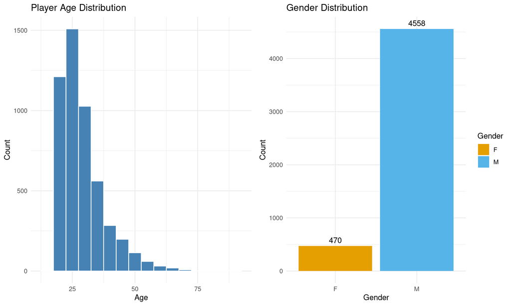

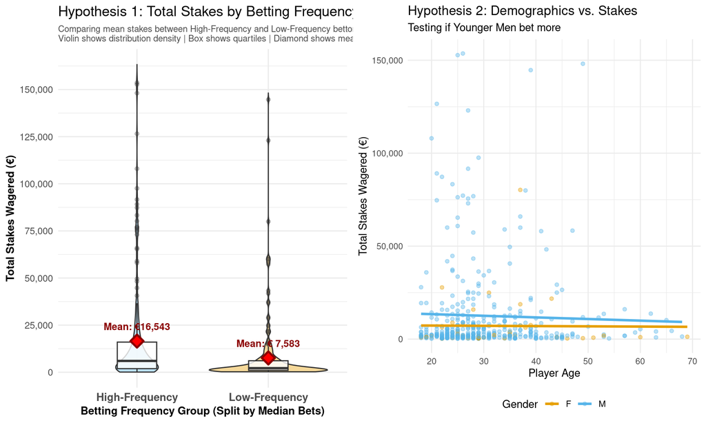

**Interpretation of Plot 3 (Hypothesis 1):**

Summary Statistics: Total Stakes by Betting Frequency

| Group | Mean Stakes (€) | Median Stakes (€) | SD Stakes (€) | N Players |
| --- | --- | --- | --- | --- |
| High-Frequency | 16,543 | 6,031 | 27,795 | 218 |
| Low-Frequency | 7,583 | 2,190 | 17,023 | 220 |

The visualization reveals several key patterns supporting our hypothesis:

- **Distribution Shape:** The violin plots show the probability density of stakes for each group. High-Frequency bettors have a wider distribution, indicating greater variability in betting amounts.
- **Central Tendency:** The red diamond marks the mean total stakes for each group. Visual inspection suggests High-Frequency bettors wager substantially more on average than Low-Frequency bettors.
- **Spread:** The box plots display quartiles (bottom, middle, and top of the box represent 25th, 50th, and 75th percentiles). The white boxes show that High-Frequency bettors have both higher medians and greater spread in their betting behavior.
- **Outliers:** Individual points outside the “whiskers” represent outliers. Both groups contain some extreme bettors, but High-Frequency bettors show more variability overall.

This visual pattern strongly suggests that betting frequency and total stakes are related, motivating our statistical test to determine if the difference in means is statistically significant.